# Exploring sample overlap simulations

```r
suppressWarnings(suppressPackageStartupMessages({
    library(simulateGP)
    library(TwoSampleMR)
    library(dplyr)
    library(ggplot2)
    library(parallel)
    library(knitr)
}))
opts_chunk$set(cache=TRUE, echo=TRUE, message=FALSE, warning=FALSE)
```

## Outline of simulation

1. Create x and y in a population
2. Find instruments for x in discovery and test for significance
3. Retest in replication
4. Extract those effects from outcome GWAS, which could be independent, discovery or replication sample

### Find GWAS parameters which will likely give high winner’s curse

```r
simulate_gwasx <- function(nid, nsnp, bgx, bux)
{
    g <- make_geno(nid, nsnp, 0.5)
    u <- rnorm(nid)
    geneff <- rep(bgx, nsnp)
    x <- make_phen(c(geneff, bux), cbind(g, u))
    gwas(x, g)
}


sapply(1:100, function(x)
{
    simulate_gwasx(3000, 20, 0.08, 0.4) %>%
    {sum(.$pval < 5e-8)}
}) %>% table
```

```
## .
##  0  1  2  3  4  5  6  7  8
##  4 13 25 20 20  8  5  4  1
```

### Check that UMVCUE works at reducing winner’s curse

```r
umvcue <- function(d_beta, r_beta, d_se, r_se, pthresh)
{
    t <- qnorm(1 - pthresh/2)
    MLE <- (r_se^2 * d_beta + d_se^2 * r_beta) / (r_se^2 + d_se^2)
    BB <- (sqrt(r_se^2 + d_se^2) / d_se^2) * (MLE - t * d_se)
    b <- MLE - (r_se^2 / sqrt(r_se^2 + d_se^2) * dnorm(BB) / pnorm(BB))
    return(b)
}


simulate_umvcue <- function(nid, nsnp, bgx, bux)
{
    geneff <- rep(bgx, nsnp)

    g <- make_geno(nid/2, nsnp, 0.5)
    u <- rnorm(nid/2)
    x <- make_phen(c(geneff, bux), cbind(g, u))
    d <- gwas(x, g)
    g <- make_geno(nid/2, nsnp, 0.5)
    u <- rnorm(nid/2)
    x <- make_phen(c(geneff, bux), cbind(g, u))
    r <- gwas(x, g)
    index <- d$pval < 5e-8
    dat <- tibble(
        truth = geneff,
        disc = d$bhat,
        rep = r$bhat,
        disc_sig = d$pval < 5e-8,
        what="all"
    )
    dat$umvcue <- NA
    if(any(index))
    {
        dat$umvcue[index] <- umvcue(d$bhat[index], r$bhat[index], d$se[index], r$se[index], 5e-8)
    }
    return(dat)
}


out <- lapply(1:100, function(x)
{
    simulate_umvcue(3000, 20, 0.13, 0.4) %>%
    mutate(sim=x)
}) %>% bind_rows()

out2 <- group_by(out, sim) %>%
    summarise(
        nsig=sum(disc_sig),
        truth=mean(truth),
        disc = mean(disc),
        rep = mean(rep),
        umvcue = mean(umvcue, na.rm=T)
    )

out3 <- filter(out, disc_sig) %>%
    group_by(sim) %>%
    summarise(
        nsig=sum(disc_sig),
        truth=mean(truth),
        disc = mean(disc),
        rep = mean(rep),
        umvcue = mean(umvcue, na.rm=T)
    )

colMeans(out2)
```

```
##        sim       nsig      truth       disc        rep     umvcue
## 50.5000000  6.9100000  0.1300000  0.1846645  0.1849242  0.1873555
```

```r
colMeans(out3)
```

```
##        sim       nsig      truth       disc        rep     umvcue
## 50.5000000  6.9100000  0.1300000  0.2234010  0.1862109  0.1873555
```

it does reduce winner’s curse, gives simular result to replication

### Run MR simulations for different sampling strategies

```r
gwas_bias <- function(gwas)
{
    # sum((gwas$bhat - gwas$b)^2)
    mean(abs(gwas$bhat - gwas$b))
}


gwas_sim <- function(nid = 9000, nsnp = 20, bgx = 0.08, bxy = 0.2, buy = 0.4, bux = 0.4, out_index = 1:3000)
{
    # Simulate population
    g <- make_geno(nid, nsnp, 0.5)
    u <- rnorm(nid)
    geneff <- rep(bgx, nsnp)
    x <- make_phen(c(geneff, bux), cbind(g, u))
    y <- make_phen(c(buy, bxy), cbind(u, x))

    # Get observational estimate
    obs_beta <- summary(lm(y ~ x))$coefficients[2,1]

    # GWAS in samples
    disc_index <- 1:3000
    rep_index <- 3001:6000
    disc_gwas <- gwas(x[disc_index], g[disc_index,])
    rep_gwas <- gwas(x[rep_index], g[rep_index,])
    out_gwas <- gwas(y[out_index], g[out_index,])

    disc_gwas$b <- geneff
    rep_gwas$b <- geneff
    out_gwas$b <- geneff * bxy

    bias <- expand.grid(sample=c("disc", "rep", "out"), what=c("all", "sig"), bias=NA)
    bias$sse[1] <- gwas_bias(disc_gwas)
    bias$sse[2] <- gwas_bias(rep_gwas)
    bias$sse[3] <- gwas_bias(out_gwas)

    # what is significant
    index <- disc_gwas$pval < 5e-8
    bias$sse[4] <- gwas_bias(disc_gwas[index,])
    bias$sse[5] <- gwas_bias(rep_gwas[index,])
    bias$sse[6] <- gwas_bias(out_gwas[index,])
    bias$nsig <- sum(index)

    # Perform MR
    d <- list()
    d$disc_all <- simulateGP::make_dat(disc_gwas, out_gwas)
    d$rep_all <- simulateGP::make_dat(rep_gwas, out_gwas)
    d$disc_sig <- simulateGP::make_dat(disc_gwas[index,], out_gwas[index,])
    d$rep_sig <- simulateGP::make_dat(rep_gwas[index,], out_gwas[index,])
    d$umvcue_sig <- d$disc_sig
    d$umvcue_sig$beta.exposure <- umvcue(d$disc_sig$beta.exposure, d$rep_sig$beta.exposure, d$disc_sig$se.exposure, d$rep_sig$se.exposure, 5e-8)

    m <- lapply(names(d), function(x) {
        y <- d[[x]]
        if(nrow(y) > 0)
        {
            z <- mr(y, method_list=c("mr_ivw", "mr_wald_ratio")) %>% as_tibble()
            z$what <- x
            return(z)
        } else {
            return(NULL)
        }
    }) %>% bind_rows()

    return(list(bias=bias, mr=m))
}


res <- lapply(1:100, function(i) {
    message(i)
    bind_rows(
        gwas_sim(out_index = 1:3000)$mr %>% mutate(overlap="disc_overlap"),
        gwas_sim(out_index = 3001:6000)$mr %>% mutate(overlap="rep_overlap"),
        gwas_sim(out_index = 3001:6000)$mr %>% mutate(overlap="no_overlap"),
        gwas_sim(out_index = 1:6000)$mr %>% mutate(overlap="both_overlap")
    )
}) %>% bind_rows()
```

Create figure

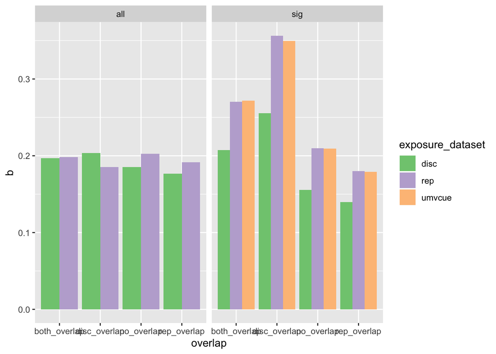

```r
ress <- filter(res) %>%
    tidyr::separate(what, into=c("exposure_dataset", "instruments"), "_") %>%
    group_by(exposure_dataset, instruments, overlap) %>%
summarise(b=mean(b), n=n(), se=sd(b)/sqrt(n))


ggplot(ress, aes(x=overlap, y=b)) +
geom_bar(stat="identity", position="dodge", aes(fill=exposure_dataset)) +
facet_grid(. ~ instruments) +
scale_fill_brewer(type="qual")
```

To do:

1. Can we add monte carlo standard errors to the figure, i.e. does UMVCUE have smaller standard error than replication?
2. Better labelling

Conclusion - How to use this for MR?

- Winner’s curse is an issue
- Sample overlap is an issue
- Weak instrument bias is an issue

Recommendation - either do

- external discovery; ukbb replication; ukbb outcome
- ukbb discovery; ukbb replication; external outcome

To do:

1. We have used extreme simulation examples. What is a more realistic result? Can we do simulations (2) and (3) using realistic data
   - e.g. 8 million SNPs, 10000 causal variants, explaning 50% variance, 400k samples
   - either very slow simulations using current method or theoretical estimates not using individual level values using code that started here https://github.com/explodecomputer/simulateGP/blob/master/R/theoretical_gwas.R
2. Perform discovery and replication in UKBB for instruments
   - this is where the GWAS results are `/mnt/storage/private/mrcieu/research/scratch/IGD/data/public/UKB-b-*/clump.txt`. It includes the complete GWAS summary data on ~400k samples, plus the clumped top hits. The task is to
     1. Go back to the original 400k individual level data
     2. Split it into two - 200k and 200k (to do this you don’t change the genetic data, you just set half the phenotype value to NA)
     3. Re-estimate the clumped effects in each of the datasets